# EP03-respuestas-equipo-3

2025-09-03

# Enunciado

## En una planta química hay dos máquinas que envasan detergentes industriales en bidones con un volumen de producto que sigue una distribución normal con desviación estándar de 1 litro. La ingeniera a cargo de la planta debe asegurar que los bidones se están llenando con una media de 10 litros. Pero ella tiene la sospecha de que hay desviaciones en esta media, lo que piensa confirmar usando una muestra aleatoria de 100 envases (50 de cada una de las máquinas). También cree que hay diferencia en el cumplimiento del volumen requerido entre la máquina más antigua y la más moderna, que han de andar por el 90% y 96% de los bidones, respectivamente.

```r
#Importación de librerias
library(ggpattern)
library(ggpubr)
library(ggplot2)
library(dplyr)
library(pwr)
```

Guardamos las variables del enunciado

```r
des_est = 1 #Desviación estándar
media = 10 #media aritmética
n_total = 100 #total de datos
n = 50 #datos por cada muestra

#Probabilidad de que se cumpla el volumen requerido en una maquina
p_o =0.9 #Máquina antigua
p_n = 0.96 #Máquina moderna
```

### 1. Si la ingeniera está seguro de que el verdadero volumen medio no puede ser superior a 10 litros y piensa rechazar la hipótesis nula cuando la muestra presente una media menor a 9,8 litros, ¿cuál es la probabilidad de que cometa un error de tipo I? Para responder, generen un gráfico de la distribución muestral de las medias hipotetizada en donde se marque la zona correspondiente a la probabilidad solicitada, para luego, basándose en este gráfico, calcular el área correspondiente. Tome como ejemplo los scripts presentados en la lectura sobre poder estadístico.

Para responder esta pregunta, primero analizamos que es lo que se quiere. La idea en este ítem es darse cuenta de que, en el inicio, hay dos afirmaciones: “seguro de que el verdadero volumen medio no puede ser superior a 10 litros” y “rechazar la hipótesis nula cuando la muestra presente una media menor a 9,8 litros”. La primera dice que está **segura** de que la media no es **superior** a 10 litros, y como consecuencia podemos despreocuparnos de este extremo en la hipótesis. Al contrario, la segunda frase menciona que el resultado de la hipótesis depende si la media muestral es **menor** a 9,8 litros, lo que implica que este extremo **si debe considerarse** en la prueba de hipótesis.

Con esto aclarado, la pregunta principal es conocer cuál es la probabilidad de cometer un error de tipo I, esto es, rechazar $H_0$ cuando es verdadera, o en el contexto del problema, la probabilidad de no darse cuenta de que el volumen medio es 10 litros. Este valor corresponde a la significancia $\alpha$.

Finalmente, para responder la pregunta se pide hacer un gráfico que modele toda esta situación. Para graficar la situación en la que trabaja la ingeniera, debemos tener en cuenta nuestra media original 10, el valor critico dado que será nuestro valor critico inferior y su área correspondiente y el error estándar de la distribución muestral, a partir de estos datos se construirá el gráfico, usando el script 7.1 de la lectura 4 del curso.

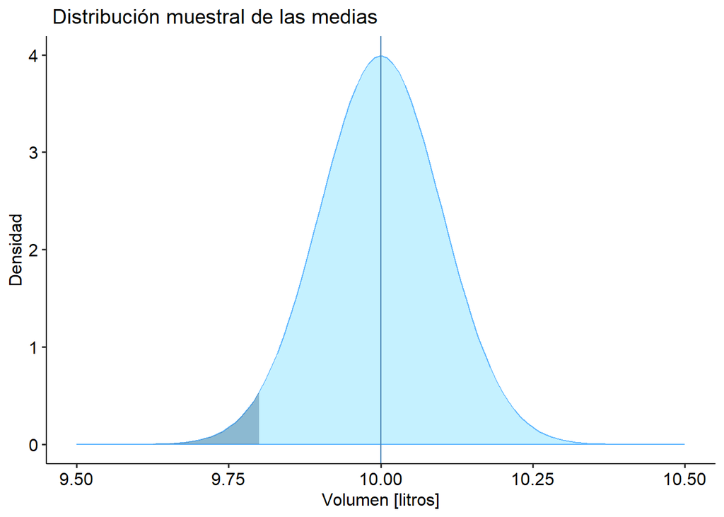

```r
#Se calcula el error estándar
SE = des_est/sqrt(n_total)


valor_critico = 9.8 # Valor crítico

#Gráfico base
g_x_limites <- media + c(-5 , 5) * SE
g <- ggplot () + xlim ( g_x_limites )
g <- g + labs ( title = " Distribución muestral de las medias " )
g <- g + labs ( x = " Volumen [litros] " , y = " Densidad " )
g <- g + theme_pubr()

dist_0 <- stat_function(fun = dnorm, geom = "area",
                        args = list(mean = media, sd = SE),
                        colour = "steelblue1", fill = "lightblue1", alpha = 0.9)

g1 <- g + dist_0
g1 <- g1 + geom_vline(xintercept = media, colour = "steelblue")

# regiones criticas
g2 <- g1 + stat_function(fun = dnorm, geom = "area",
                         args = list(mean = media, sd = SE),
                         xlim = c(g_x_limites[1], valor_critico),
                         fill = "steelblue4", alpha = 0.4)

print(g2)
```

Una vez obtenido el gráfico, podemos calcular la probabilidad de rechazar incorrectamente la hipótesis nula. Para esto, debemos recordar algunas definiciones básicas. El valor 9,8 es el **valor crítico**, con el cuál se decide si rechazar o no la hipótesis nula, y actúa como el límite entre rechazar o no la hipótesis de una cola. El área externa de la cola es la probabilidad $\alpha$ de cometer un error de tipo I.

Procedemos a calcular esta probabilidad.

```r
#Se calcula alfa
prob_tipo1 <- pnorm(q = valor_critico, mean = media, sd = SE, lower.tail = TRUE)
cat("La probabilidad de cometer un error de tipo I es:", prob_tipo1)
```

```
## La probabilidad de cometer un error de tipo I es: 0.02275013
```

### 2. Si el verdadero volumen medio de los bidones fuera de 9,85 litros, ¿cuál sería la probabilidad de que la ingeniera, que obviamente no conoce este dato, cometa un error de tipo II? Para responder, agregue al gráfico anterior la verdadera distribución muestral de las medias y marquen (con otro color) la zona correspondiente a la probabilidad solicitada, para luego, basándose en este gráfico, calcular el área correspondiente. También hay ejemplos de este procedimiento en la lectura sobre poder estadístico.

Para responder la pregunta se debe saber que un error de tipo II corresponde a no rechazar la hipótesis nula $H_{0}$ en favor de la hipótesis alternativa $H_{A}$ cuando esta última es verdadera, usualmente se utiliza beta $\beta$ para representarlo. Para identificar esto, junto con el gráfico de la pregunta anterior, se grafica la distribución muestral con la media verdadera 9,85 identificando la ubicación de esta media e identificando el valor $\beta$ dentro de la gráfica.

[figure not shown]

```r
#Media verdadera
media_v = 9.85
#Delta
delta = media-media_v
#alpha
alpha = prob_tipo1

z_sup = qnorm(alpha, mean = media, sd= SE, lower.tail = FALSE)

#Se agrega la gráfica de la distribución muestral con la media verdadera
g3 <- g2 + stat_function(fun = dnorm, geom = "area",
                        args = list(mean = media_v, sd = SE),
                        colour = "steelblue1", fill = "steelblue1", alpha = 0.2)

#Se agrega linea ubicada en la media verdadera
g3 <- g3 + geom_vline(xintercept = media_v, colour = "steelblue1")

#Se agrega área Beta
g3 <- g3 + stat_function(fun = dnorm, geom = "area_pattern",
                         args = list(mean=media_v, sd = SE),
                         #xlim = c(media_m, z_sup),
                         xlim = c(valor_critico, z_sup),
                         fill = "white", colour = "steelblue", alpha = 0.3,
                         pattern_spacing = 0.15, pattern_density = 0.4,
                         pattern_fill = "steelblue", pattern_colour = "steelblue",
                         pattern_angle = 45, pattern_alpha= 0.3)

g3
```

En la gráfica, el área rayada representa $\beta$ que es la probabilidad de cometer un error de tipo II, se puede observar que es un valor mayor al 50% de la distribución muestral de la media verdadera. Para calcular su valor, se calcula el poder total (probabilidad de correctamente rechazar la hipótesis nula $H_{0}$ cuando es falsa) con la media verdadera, y así obtener beta con la ecuación $poder=1-\beta$.

```r
#Se calcula el poder
poder_inf <- pnorm(valor_critico, mean = media_v, sd = SE, lower.tail = TRUE)
poder_sup <- pnorm(z_sup, mean = media_v, sd = SE, lower.tail = FALSE)
poder = poder_inf+poder_sup
beta = 1-poder
cat("La probabilidad de obtener un error de tipo II es:", beta)
```

```
## La probabilidad de obtener un error de tipo II es: 0.6912298
```

Los resultados dados son que la probabilidad de que la ingeniera cometa un error de tipo II es de 69%, en otras palabras tiene un 69% de que no rechace la hipótesis nula en favor de la hipótesis alternativa cuando esta última es verdadera, el valor alto se explica debido a que $\beta$ y $\alpha$ son inversamente proporcionales, mientras más alto sea el valor de uno más bajo será el valor del otro, en este caso tenemos un $\alpha$ bastante pequeño y un beta de gran tamaño cumpliendo la proporción.

### 3. Como no se conoce el verdadero volumen medio, genere un gráfico del poder estadístico con las condiciones anteriores, pero suponiendo que el verdadero volumen medio podría variar de 9,5 a 10 litros. Hay un ejemplo de este tipo de gráfico en la lectura sobre poder estadístico.

Con esta pregunta regresamos al escenario original de no conocer la media de la población. Se nos pide graficar el poder de la prueba, pero con la condición que la verdadera media de la población varía entre los valores 9,5 a 10 litros.

Para esta pregunta, y en específico para el supuesto de la variación de la media poblacional, es conveniente recordar otro concepto importante, el **tamaño del efecto** $\delta$, el que se define como la diferencia, o distancia, entre dos variables. Como la investigación de la ingeniera está relacionada con la media de los volúmenes de bidones, el tamaño del efecto en esta prueba es la diferencia entre la media nula y la media real $\delta=\mu_{real}-\mu_{0}$.

Regresando con la confección del gráfico, está claro que, ya que el tamaño del efecto relaciona directamente la media real con la nula, es conveniente relacionar la potencia con el tamaño del efecto. Para esto, nos basamos en el script 7.4 para crear el gráfico 7.5 (lectura 4 de la clase) que relaciona poder estadístico con el tamaño del efecto.

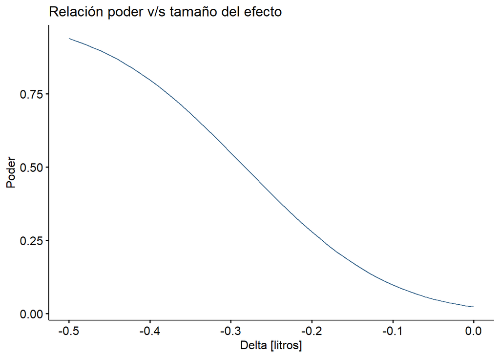

```r
library(pwr)

#Tamaños del efecto
medias_verdaderas <- seq(9.5, 10, 0.01)
deltas <- medias_verdaderas - media
deltas_normalizados <- deltas / des_est

#Función para calcular el poder para cada delta
fun_poder_efecto <- function(x) pwr.norm.test(x, n = n, sig.level = prob_tipo1, alternative = "less")[["power"]]
eje_poder <- sapply(deltas_normalizados, fun_poder_efecto)

#Graficar
relacion_poder_efecto <- data.frame(deltas = deltas, eje_poder = eje_poder)
g <- ggline(relacion_poder_efecto, x = "deltas", y = "eje_poder", plot_type = "l",
            numeric.x.axis = TRUE, title = "Relación poder v/s tamaño del efecto",
            xlab = "Delta [litros]", ylab = "Poder", color = "steelblue4")

g
```

Si bien este gráfico sirve para mostrar la relación entre el poder estadístico y el valor real de la media, a través del tamaño del efecto, empleando la ecuación $\delta=\mu_{real}-\mu_{0}$ podemos hacer un gráfico más claro usando directamente las medias reales.

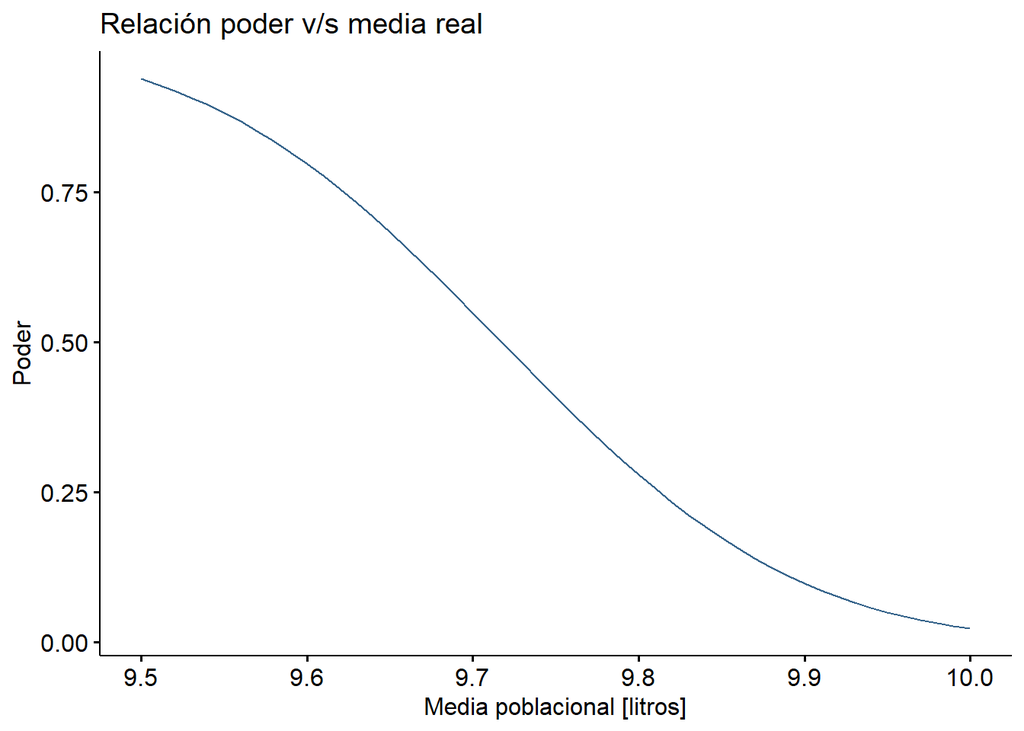

```r
relacion_poder_mreal <- data.frame(medias_verdaderas = medias_verdaderas, eje_poder = eje_poder)
g <- ggline(relacion_poder_mreal, x = "medias_verdaderas", y = "eje_poder", plot_type = "l",
            numeric.x.axis = TRUE, title = "Relación poder v/s media real",
            xlab = "Media poblacional [litros]", ylab = "Poder", color = "steelblue4")

g
```

Con este gráfico logramos ver fácilmente la relación entre el poder estadístico y el valor de la media real. Mientras más bajo es el valor de la media real, mayor es el poder, y viceversa. Cabe destacar que, en el punto 2 del informe, se encuentra implícitamente la explicación de porque sucede esto. La razón de porque sucede esto es que, mientras más lejos a la izquierda esté la media real de la nula, el área del poder es mayor, y al contrario, mientras más a la derecha esté la media real, el área del poder disminuye.

### 4. Considerando un volumen medio de 10 litros, ¿cuántos bidones deberían revisarse para conseguir un poder estadístico de 0,75 y un nivel de significación de 0,05?

La pregunta 4 de esta tarea ya no se trata sobre la media. Lo que se quiere conocer es la cantidad de bidones para cumplir ciertas condiciones, y estas son obtener un poder estadístico y nivel de significancia específicos; entonces lo que nos interesa es el tamaño de la muestra de bidones.

Las hipótesis a contrastar son:

- Hipótesis nula: El volumen medio de llenado de los bidones es de 10 litros.
  $$H_{0}: \mu=10$$
- Hipótesis alternativa: El volumen medio de llenado de los bidones es menor a 10 litros
  $$H_{A}: \mu <
  10$$

Para encontrar la cantidad de observaciones solicitada, primero debemos pensar en algunos parámetros de la prueba. Primero, como la hipótesis alternativa es si la media real es menor al valor teórico, el argumento “alternative” debe ser “less” en la función. Luego con lo gráficos hechos en la pregunta anterior se hace una estimación de la media real para calcular el tamaño del efecto, para ello en el gráfico Relación poder v/s media poblacional se ven los valores cercanos a un poder de 0,75, a partir de estos tomamos el valor 9,62 como media real.

Con los datos ya tomados realizamos la prueba.

```r
#Medidas fijas
verdad = 9.62
delta = verdad - media
tam_efecto_norm = delta / des_est
significancia <- 0.05
poder <- 0.75

#Los factores
factores <- pwr.norm.test(d = tam_efecto_norm, sig.level = significancia, power = poder, alternative = "less")
factores
```

```
##
##      Mean power calculation for normal distribution with known variance
##
##               d = -0.38
##               n = 37.25314
##       sig.level = 0.05
##           power = 0.75
##     alternative = less
```

La prueba hecha indica que se necesitan 38 bidones en cada muestra para conseguir un nivel de significancia de 0,05 y un poder de 0,75.

### 5. ¿Alcanzaría esta muestra para detectar la diferencia que la ingeniera sospecha que existe entre las dos máquinas de la planta con al menos las mismas probabilidades de cometer errores?

Para responder esta pregunta tenemos que tener en consideración los datos calculados anteriormente, si el número de bidones $n=38$ por máquina es suficiente para detectar la diferencia en el cumplimiento del volumen requerido en las máquinas usando las mismas probabilidades de cometer errores (usando mismo nivel de significancia y poder de la pregunta anterior), también se debe tomar en cuenta las probabilidades que sospecha la ingeniera de que las maquinas cumplan con el volumen requerido 90% y 96% para la máquina más antigua y más moderna respectivamente.

Para ello si usamos dos muestras, ambas de 38 bidones, de las dos máquinas con el mismo nivel de significancia 0,05 se debería obtener un poder igual o mayor al entregado anteriormente.

Lo que se quiere saber, es si existe una diferencia entre la probabilidad de cumplir con el volumen requerido de la máquina más antigua con la máquina más moderna, entonces se formulan las siguientes hipótesis.

- Hipótesis nula: La probabilidad de cumplir con el volumen requerido de los bidones de la máquina más antigua $p_{1}$ es igual a la probabilidad de la máquina más moderna $p_{2}$
  $$H_{0}: p_{1} = p_{2}$$
- Hipótesis alternativa: La probabilidad de cumplir con el volumen requerido de los bidones de la máquina más antigua $p_{1}$ no es igual a la probabilidad de la máquina más moderna $p_{2}$
  $$H_{A}: p_{1} \ne p_{2}$$
  La hipótesis alternativa planteada sugiere una prueba bilateral, junto que tenemos que considerar las sospechas de probabilidades de que se llenen correctamente los bidones por cada maquina, y que las muestras son de igual tamaño, se considera realizar una prueba de diferencia de dos proporciones de igual tamaño, debido a la naturaleza dicotómica de que se cumpla o no el volumen de los bidones, y con ello verificar el poder resultante cuando las muestras tienen un tamaño de 38 bidones, el poder nos indicara las probabilidades que tiene la ingeniera de rechazar correctamente la hipótesis nula en favor de la hipótesis alternativa, en otras palabras, detectar la diferencia entre ambas probabilidades.

Para ello realizamos la prueba anteriormente mencionada.

```r
#Número de bidones por muestra
n_muestra = 38
#se calcula h de Cohen
h_Cohen = ES.h(p_o, p_n)

#Se realiza el test, dejando el valor power nulo para calcular su valor
factores = pwr.2p.test(h = h_Cohen, n=n_muestra, sig.level = significancia, alternative = "two.sided")
factores
```

[output not shown]

Los resultados dados por el test indican un poder aproximado de 0,18, un poder mucho menor al dado en la pregunta anterior 0,75, este valor apunta a una muy baja probabilidad de que la ingeniera pueda detectar una diferencia en el cumplimiento de volumen requerido en los bidones.

Por lo tanto, la respuesta final a esta pregunta es: no, esta muestra es insuficiente para detectar la diferencia entre ambas máquinas.